# Reproducible Research Part 1

Chelsi Snellen

October 20, 2019

# Load in the Data

```r
data_path <- "activity.csv"
activity_data <- read.csv(data_path)
```

# What is the mean total of steps taken per day?

## Calculate the number of steps taken per day

```r
# Count the total number of steps by day
by_date <- aggregate(activity_data["steps"],by=activity_data["date"], sum)

# Remove rows with NA values
by_date <- na.omit(by_date)
```

## Make a histogram of the total number of steps taken each day

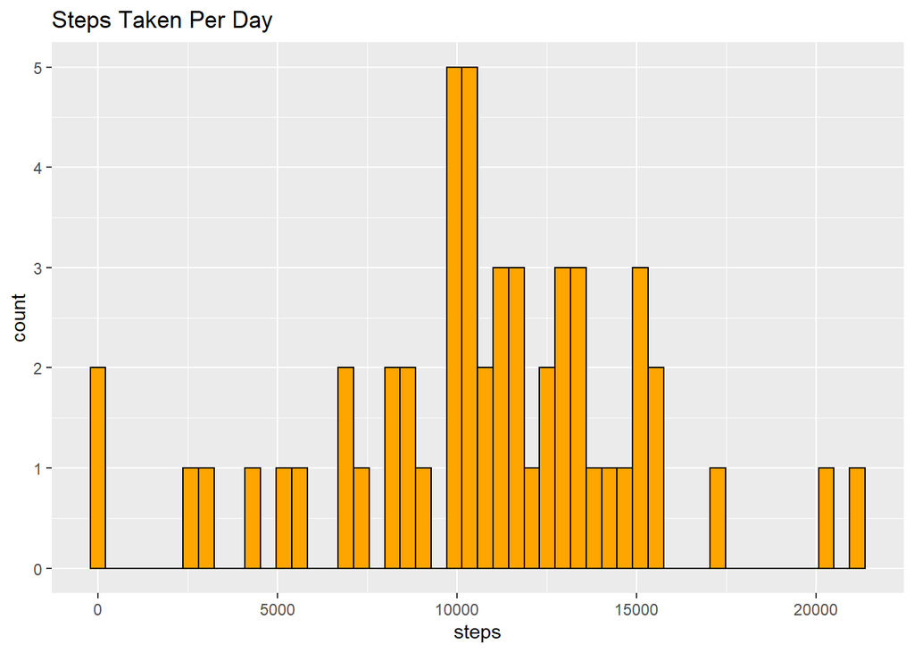

```r
# Plot the total number of steps taken per day
g <- ggplot(by_date, aes(x = steps)) + geom_histogram(color = "black", fill = "orange", bins = 50) + ggtitle("Steps Taken Per Day")
g
```

## Calculate and report the mean and median of the total number of steps taken per day

```r
# Calcualte the mean total steps
mean_steps <- mean(by_date$steps)
```

### Mean Steps per Day

```r
mean_steps
```

```
## [1] 10766.19
```

```r
# Calculate the median total steps
median_steps <- median(by_date$steps)
```

### Median Steps per day

```r
median_steps
```

```
## [1] 10765
```

# What is the average daily pattern?

## Make a time series plot (i.e. type=“l”) of the 5-minute interval (x-axis) and the average number of steps taken, averaged across all days (y-axis)

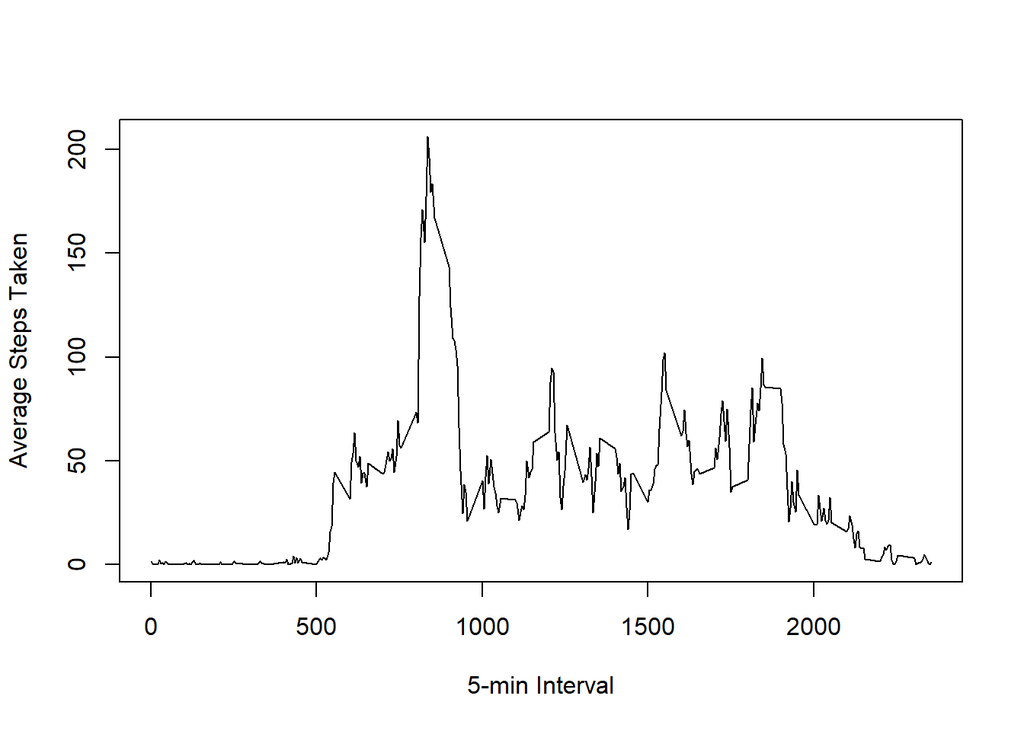

```r
# calculate mean steps by interval
x <- aggregate(steps ~ interval, activity_data, mean, na.rm=TRUE)

# plot the line chart and label
plot(x, type="l", xlab="5-min Interval", ylab="Average Steps Taken")
```

## Which 5-minute interval, on average across all the days in the dataset, contains the maximum number of steps?

```r
#Report the interval with the largest number of steps
x$interval[x$steps==max(x$steps)]
```

```
## [1] 835
```

# Imputing Missing Values

## Calculate and report the total number of missing values in the dataset (i.e. the total number of rows with NAs)

```r
# Sum the number of NA values
sum(is.na(activity_data$steps))
```

```
## [1] 2304
```

## Devise a strategy for filling in all of the missing values in the dataset. The strategy does not need to be sophisticated. For example, you could use the mean/median for that day, or the mean for that 5-minute interval, etc.

The missing days seem to be for whole days so the NA values will be replaced with zeros

## Create a new dataset that is equal to the original dataset but with the missing data filled in.

```r
# create the new table to impute values for NA
imputed <- activity_data
# substitute NA with zero
imputed$steps[is.na(imputed$steps)] <- 0
# cross check, no NA's
sum(is.na(imputed$steps))
```

```
## [1] 0
```

```r
# cross check again, total entries add up to data set
sum(!is.na(imputed$steps))
```

```
## [1] 17568
```

## Make a histogram of the total number of steps taken each day and Calculate and report the mean and median total number of steps taken per day. Do these values differ from the estimates from the first part of the assignment? What is the impact of imputing missing data on the estimates of the total daily number of steps?

### Plot the histogram

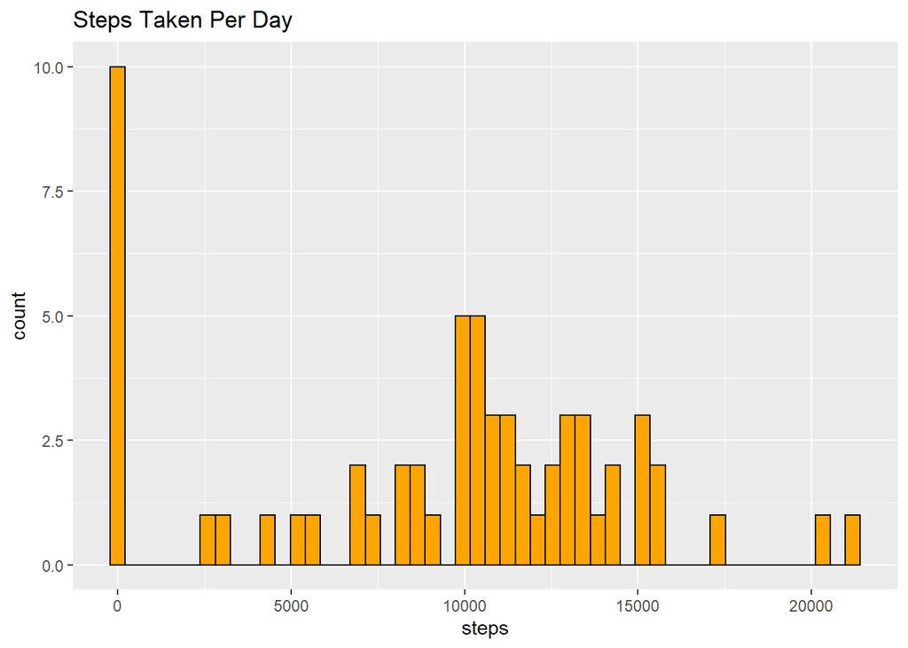

```r
# Count the total numbers of steps per day
by_date <- aggregate(imputed["steps"],by=imputed["date"], sum)

# Plot a histogram of the steps
g <- ggplot(by_date, aes(x = steps)) + geom_histogram(color = "black", fill = "orange", bins = 50) + ggtitle("Steps Taken Per Day")
g
```

### Report the mean and median

```r
# Report the mean
mean(by_date$steps)
```

```
## [1] 9354.23
```

```r
# Report the median
median(by_date$steps)
```

```
## [1] 10395
```

### Analysis

#### Do these values differ from the first part of the assigment?

- Yes, by including the imputed values the mean and median steps taken per steps decreased.

#### What is the impact of imputing missing data on the estimates of the total daily number of steps?

- The imputed values decreased the estimates of the total daily number of steps